# 4545 Team League: Season 37

[figure not shown]

### Overview

This [season’s](https://www.lichess4545.com/team4545/season/37/summary/) games were played between 23 October 2023 and 18 December 2023.

431 players participated, 94 (22%) of whom were new to the league.

42 teams played 168 matches over the season’s eight weeks. 30 matches (18%) were drawn, and 49 (29%) were won by just a single point.

In all, 1,263 games were played over the season. The season’s ‘unplayed pairing’ rate was 6%.[^1]

White won 504 games (39.9%), 196 games (15.5%) were drawn, and Black won 534 games (42.3%). The right-hand chart shows game results by colour for each board or average rating band.[^2]

[figure not shown]

### Final standings

1st place

[b2 or not b2](https://www.lichess4545.com/team4545/season/37/team/35/)

15 pts (44.5 GP)

2nd place

[CarlsBad Boys](https://www.lichess4545.com/team4545/season/37/team/23/)

13 pts (37 GP)

3rd place

[Caissa Explains It All](https://www.lichess4545.com/team4545/season/37/team/22/)

12 pts (35.5 GP)

*Podium team rosters (incl. alternates, ordered by games played)*

| Gold | Silver | Bronze |
| --- | --- | --- |
| HunterDavis (8) | paulinesernine (8) | Anthammer (8) |
| SlowChess73 (8) | Sidewinder1648 (7) | Groger12 (8) |
| Zubenelgenubi (8) | Storf (7) | Silkthewanderer (8) |
| alp_arslan92 (8) | adande1 (7) | Three-Arrows (8) |
| jg777 (8) | smothermemate (7) | alex11star (8) |
| mason52301 (8) | i2q0 (6) | fulmarsky (8) |
| jantho (7) | mysonnevercallme (5) | mqll (8) |
| ipr (5) | minioo (4) | HeartCooksBrain (7) |
| bagelkh (1) | Akshak (1) |  |
| chuckbrother (1) | Jelle1 (1) |  |

[output cut: 5 more lines]

#### How the title race played out

[figure not shown]

**Match stories**

See the twists and turns in every match this season through these PDF visualisations…assuming they’ve already been created and uploaded. [Source script](https://github.com/rahulan-c/lichess4545-stats/blob/2783e66cd6f257ea4ac2c1fcfaa30037887097b0/R/plot_match_story.R).

Round 1 | Round 2 | Round 3 | Round 4 | Round 5 | Round 6 | Round 7 | Round 8

### Top players

#### Board medals

Here are the top three player performances on each board (min. 5 games played). Click on the arrows next to each board number to see more details.[^3]

| Board | Player(s) | Games | Points | Board Perf. |
| --- | --- | --- | --- | --- |
| 1 | Aidoz | 8 | 6.5 | 2460.75 |
| 1 | Leverkuhn | 8 | 6 | 2443.75 |
| 1 | Mediocratic | 6 | 4.5 | 2395.16666666667 |
| 2 | ZatteWilly | 8 | 7 | 2418.125 |
| 2 | sebb7y | 7 | 6 | 2393.42857142857 |
| 2 | Think_Slow_Move_Slow | 5 | 4 | 2303.4 |
| 3 | Sparassidae | 5 | 4.5 | 2331.8 |
| 3 | lc69 | 8 | 7 | 2320.875 |
| 3 | leartt | 7 | 6 | 2309.57142857143 |
| 4 | Feet_Barbie | 8 | 7 | 2260.125 |

[output cut: 14 more lines]

#### Best scorers

Here’s everyone who achieved a plus score of +5 or higher this season[^4]:

**Sacul2193** (8/9), **Apidae** (7/8), **Feet_Barbie** (7/8), **Sparassidae** (7/8), **ZatteWilly** (7/8), **lc69** (7/8), **runken_brunflo** (7/8), **Aidoz** (6.5/8), **HunterDavis** (6.5/8), **Nairwolf** (6/7), **Scaredpeach** (6/7), **chessunable** (6.5/8), **far1108** (6/7), **jg777** (6/7), **johnnyzangerous** (6.5/8), **sebb7y** (6/7)

Players with plus scores of +6 or better get the **Ace** award.

### Stats - overview

#### Timing

[figure not shown]

#### Length

[figure not shown]

#### Most moves

*Includes games ranked at or above the 90th percentile by number of moves.*

| Rank | Players / Link | Date | Moves |
| --- | --- | --- | --- |
| 1 | mronemore - chk12 | Wed 8 Nov 2023 | 104 |
| 2 | reddevil906 - Queen_of_Hearts75 | Wed 25 Oct 2023 | 100 |
| 3 | Quantex_seven - TimothyHa | Sat 28 Oct 2023 | 94 |
| 3 | widp - samuelglats | Mon 18 Dec 2023 | 94 |
| 5 | ChessForWellbeing - ajajajaj | Sun 26 Nov 2023 | 93 |
| 6 | bufferunderrun - chatakkuma | Fri 1 Dec 2023 | 92 |
| 7 | yellorambo - p_s_q | Sun 29 Oct 2023 | 90 |
| 8 | AumarMustafa - aloo_bhaloo | Sun 3 Dec 2023 | 88 |
| 9 | RSInternecio - Sarkerq | Tue 21 Nov 2023 | 87 |
| 10 | Quantex_seven - Pughie | Sat 2 Dec 2023 | 86 |

[output cut: 122 more lines]

#### Longest games

*Includes games ranked at or above the 90th percentile by total clock time.*[^5]

| Rank | Players / Link | Date | Total time |
| --- | --- | --- | --- |
| 1 | mronemore - chk12 | Wed 8 Nov 2023 | 3h 47m 57s |
| 2 | bufferunderrun - chatakkuma | Fri 1 Dec 2023 | 3h 31m 44s |
| 3 | ChessForWellbeing - ajajajaj | Sun 26 Nov 2023 | 3h 23m 17s |
| 4 | x420noscope - NebraskaNarwhal | Tue 28 Nov 2023 | 3h 21m 29s |
| 5 | HunterDavis - winegum1994 | Wed 22 Nov 2023 | 3h 21m 27s |
| 6 | RSInternecio - Sarkerq | Tue 21 Nov 2023 | 3h 12m 24s |
| 7 | chatakkuma - chk12 | Thu 23 Nov 2023 | 3h 12m 23s |
| 8 | bushie123 - STCLion | Wed 15 Nov 2023 | 3h 11m 59s |
| 9 | Lutin23 - DosDebug | Sat 11 Nov 2023 | 3h 11m 38s |
| 10 | momor - jsprae | Thu 16 Nov 2023 | 3h 11m 31s |

[output cut: 122 more lines]

### Stats - by board/rating

#### ACPL and blunder rate

[figure not shown]

#### Lowest combined ACPL

The games with the lowest combined ACPL (including draws).

| Board | Players / Link | Result | Sum ACPL | Date |
| --- | --- | --- | --- | --- |
| 1 | x420noscope - sterpfi | 1/2-1/2 | 11 | Fri 27 Oct 2023 |
| 2 | Arges42 - birdpersson | 1/2-1/2 | 12 | Wed 15 Nov 2023 |
| 3 | far1108 - Three-Arrows | 1/2-1/2 | 10 | Thu 23 Nov 2023 |
| 4 | adande1 - esersens | 1/2-1/2 | 7 | Sun 17 Dec 2023 |
| 5 | ajajajaj - Moccy | 1/2-1/2 | 15 | Tue 12 Dec 2023 |
| 6 | yairjazz - Nestor3690 | 1/2-1/2 | 14 | Wed 25 Oct 2023 |
| 7 | EnglishSpaniel - BigPig93 | 0-1 | 36 | Sun 3 Dec 2023 |
| 8 | davegiltinan - TCD8 | 1/2-1/2 | 26 | Thu 7 Dec 2023 |

#### Decisive games only

The *decisive* games with the lowest combined ACPL.

| Board | Players / Link | Result | Sum ACPL | Date |
| --- | --- | --- | --- | --- |
| 1 | arthi15 - Dogue-Brabo | 1-0 | 28 | Sat 2 Dec 2023 |
| 2 | Mago1 - ComputerUser2607 | 1-0 | 30 | Sun 26 Nov 2023 |
| 3 | Goatsrock - stevy | 1-0 | 29 | Fri 17 Nov 2023 |
| 4 | esersens - Constant1n | 1-0 | 28 | Tue 31 Oct 2023 |
| 5 | Rskyoz - winegum1994 | 0-1 | 34 | Sun 3 Dec 2023 |
| 6 | yairjazz - Jjames1 | 0-1 | 22 | Sat 11 Nov 2023 |
| 7 | EnglishSpaniel - BigPig93 | 0-1 | 36 | Sun 3 Dec 2023 |
| 8 | Lexgrad - Nairwolf | 0-1 | 35 | Sun 19 Nov 2023 |

### Openings

#### First moves

The frequency of first move pairs by board (4545) or average rating band (LoneWolf).

[figure not shown]

#### Top openings

All openings played in the season, excluding variations.

| rank | opening.broad | games | perc_w | white_wins | draws | black_wins | mean_eval_after_15 | mean_rating |
| --- | --- | --- | --- | --- | --- | --- | --- | --- |
| 1 | Sicilian Defense | 213 | 46.4788732394366 | 37.5586854460094 | 17.8403755868545 | 44.6009389671362 | 0.388357487922705 | 1892.57276995305 |
| 2 | Caro-Kann Defense | 182 | 44.5054945054945 | 37.3626373626374 | 14.2857142857143 | 48.3516483516484 | 0.412542372881356 | 1873.47527472527 |
| 3 | English Opening | 87 | 53.448275862069 | 43.6781609195402 | 19.5402298850575 | 36.7816091954023 | 0.313372093023256 | 1906.68390804598 |
| 4 | Queen's Gambit Declined | 62 | 50 | 43.5483870967742 | 12.9032258064516 | 43.5483870967742 | 0.411166666666667 | 1834.99193548387 |
| 5 | Queen's Pawn Game | 59 | 54.2372881355932 | 45.7627118644068 | 16.9491525423729 | 37.2881355932203 | 0.488448275862069 | 1824.29661016949 |
| 6 | French Defense | 57 | 48.2456140350877 | 40.3508771929825 | 15.7894736842105 | 43.859649122807 | 0.395714285714286 | 1869.15789473684 |
| 7 | Indian Defense | 44 | 43.1818181818182 | 36.3636363636364 | 13.6363636363636 | 50 | 0.223720930232558 | 1914.53409090909 |
| 8 | Italian Game | 37 | 47.2972972972973 | 32.4324324324324 | 29.7297297297297 | 37.8378378378378 | 0.362777777777778 | 1879.12162162162 |
| 9 | Ruy Lopez | 36 | 61.1111111111111 | 52.7777777777778 | 16.6666666666667 | 30.5555555555556 | 0.431111111111111 | 1883.11111111111 |
| 10 | King's Indian Defense | 32 | 46.875 | 37.5 | 18.75 | 43.75 | 0.5953125 | 1877.46875 |

[output cut: 64 more lines]

#### Best for White

White’s top-scoring openings, excluding variations. *Minimum 10 games played.*

| rank | opening.broad | games | perc_w | white_wins | draws | black_wins | mean_eval_after_15 | mean_rating |
| --- | --- | --- | --- | --- | --- | --- | --- | --- |
| 1 | Russian Game | 18 | 66.6666666666667 | 61.1111111111111 | 11.1111111111111 | 27.7777777777778 | 0.895882352941177 | 1845.55555555556 |
| 2 | Catalan Opening | 15 | 63.3333333333333 | 46.6666666666667 | 33.3333333333333 | 20 | 0.35 | 1881.8 |
| 3 | Modern Defense | 12 | 62.5 | 58.3333333333333 | 8.33333333333333 | 33.3333333333333 | 0.473333333333333 | 1877.20833333333 |
| 4 | Scandinavian Defense | 25 | 62 | 56 | 12 | 32 | 0.25304347826087 | 1851.64 |
| 5 | Ruy Lopez | 36 | 61.1111111111111 | 52.7777777777778 | 16.6666666666667 | 30.5555555555556 | 0.431111111111111 | 1883.11111111111 |
| 6 | Pirc Defense | 23 | 56.5217391304348 | 47.8260869565217 | 17.3913043478261 | 34.7826086956522 | 0.336521739130435 | 1758.71739130435 |
| 7 | Queen's Pawn Game | 59 | 54.2372881355932 | 45.7627118644068 | 16.9491525423729 | 37.2881355932203 | 0.488448275862069 | 1824.29661016949 |
| 8 | English Opening | 87 | 53.448275862069 | 43.6781609195402 | 19.5402298850575 | 36.7816091954023 | 0.313372093023256 | 1906.68390804598 |
| 9 | Dutch Defense | 15 | 53.3333333333333 | 46.6666666666667 | 13.3333333333333 | 40 | 0.588 | 1741.73333333333 |
| 10 | Four Knights Game | 31 | 50 | 45.1612903225806 | 9.67741935483871 | 45.1612903225806 | 0.48258064516129 | 1831.5 |

[output cut: 13 more lines]

#### Best for Black

Black’s top-scoring openings, excluding variations. *Minimum 10 games played.*

| rank | opening.broad | games | perc_b | black_wins | draws | white_wins | mean_eval_after_15 | mean_rating |
| --- | --- | --- | --- | --- | --- | --- | --- | --- |
| 1 | Nimzo-Indian Defense | 21 | 69.0476190476191 | 57.1428571428571 | 23.8095238095238 | 19.047619047619 | 0.4075 | 1921.61904761905 |
| 2 | Rapport-Jobava System | 22 | 63.6363636363636 | 59.0909090909091 | 9.09090909090909 | 31.8181818181818 | 0.301428571428571 | 1790.54545454545 |
| 3 | Zukertort Opening | 18 | 58.3333333333333 | 55.5555555555556 | 5.55555555555556 | 38.8888888888889 | 0.151176470588235 | 1872.36111111111 |
| 4 | Indian Defense | 44 | 56.8181818181818 | 50 | 13.6363636363636 | 36.3636363636364 | 0.223720930232558 | 1914.53409090909 |
| 5 | Caro-Kann Defense | 182 | 55.4945054945055 | 48.3516483516484 | 14.2857142857143 | 37.3626373626374 | 0.412542372881356 | 1873.47527472527 |
| 6 | Vienna Game | 24 | 54.1666666666667 | 50 | 8.33333333333333 | 41.6666666666667 | 0.509583333333333 | 1769.14583333333 |
| 7 | Slav Defense | 28 | 53.5714285714286 | 42.8571428571429 | 21.4285714285714 | 35.7142857142857 | 0.3136 | 1903.41071428571 |
| 8 | Sicilian Defense | 213 | 53.5211267605634 | 44.6009389671362 | 17.8403755868545 | 37.5586854460094 | 0.388357487922705 | 1892.57276995305 |
| 9 | Scotch Game | 29 | 53.448275862069 | 44.8275862068966 | 17.2413793103448 | 37.9310344827586 | 0.347142857142857 | 1806.41379310345 |
| 10 | King's Indian Defense | 32 | 53.125 | 43.75 | 18.75 | 37.5 | 0.5953125 | 1877.46875 |

[output cut: 13 more lines]

#### Top gambits

The most played gambits over the season.[^6]

| Rank | Name | Games | White score (%) |
| --- | --- | --- | --- |
| 1 | Smith-Morra Gambit | 11 | 59.0909090909091 |
| 2 | Scotch Gambit | 8 | 43.75 |
| 3 | Milner-Barry Gambit | 7 | 50 |
| 4 | Queen's Gambit Accepted | 6 | 41.6666666666667 |
| 5 | King's Gambit | 5 | 70 |
| 6 | Evans Gambit | 4 | 75 |
| 7 | Rio Gambit | 3 | 100 |
| 8 | Göring Gambit | 3 | 66.6666666666667 |
| 9 | Wing Gambit | 3 | 33.3333333333333 |
| 10 | Greco Gambit | 3 | 16.6666666666667 |

[output cut: 25 more lines]

#### Gambiteers

The players who enjoyed the most success when playing gambits.[^7] *Includes everyone who scored at least 50 per cent across at least two gambit games.*

| Rank | Player | Games | % Score | W | B | Choices |
| --- | --- | --- | --- | --- | --- | --- |
| 1 | LeoYee | 3 | 83.3333333333333 | 3 | 0 | Smith-Morra Gambit |
| 1 | paulinesernine | 3 | 83.3333333333333 | 3 | 0 | Göring Gambit, Evans Gambit, Smith-Morra Gambit |
| 2 | Seb32 | 3 | 66.6666666666667 | 2 | 1 | Göring Gambit, Danish Gambit, Ulvestad Variation (Two Knights) |
| 3 | mojomoe | 3 | 50 | 3 | 0 | Smith-Morra Gambit, Scotch Gambit, Milner-Barry Gambit |
| 4 | Zhess | 2 | 100 | 1 | 1 | Traxler Counterattack, von der Lasa Gambit |
| 4 | pantofeller | 2 | 100 | 2 | 0 | Evans Gambit |
| 5 | BernardLunder | 2 | 75 | 2 | 0 | Scotch Gambit |
| 6 | GlennJamesMax | 2 | 50 | 1 | 1 | King's Gambit, Englund Gambit |
| 6 | glbert | 2 | 50 | 1 | 1 | Queen's Gambit, Budapest Defense |

### Openings sunburst

Click on the image below to see a sunburst plot of all openings played in the season.

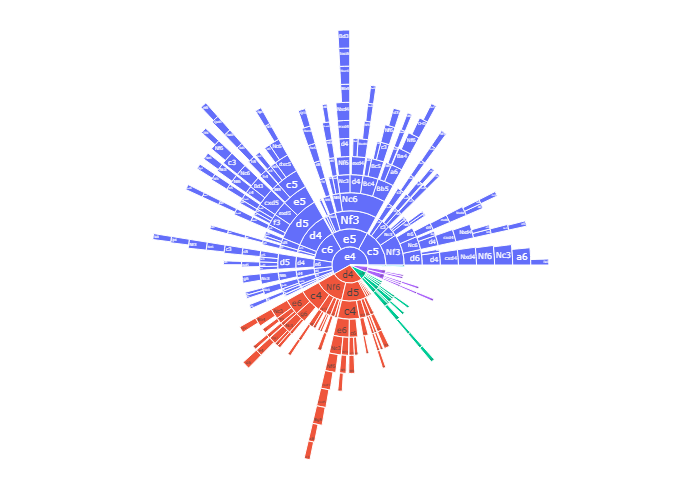

### Awards

Assorted awards to celebrate the season - see the footnote for more details.[^8]

| Award | Name / Description | Winner(s) | Runner(s)-up |
| --- | --- | --- | --- |
| x | Aces | Apidae, Feet_Barbie, lc69, runken_brunflo, Sacul2193, Sparassidae, ZatteWilly |  |
| x | Archbishop of Accuracy | Arges42 | PortyM, Sooneroo |
| x | Awesome Alt | plastic_pusher | ekopp2000 (5) |
| x | Bullet Boss | NLance | ragnarokgame, CrazyMerlyn |
| x | David Award | TimothyHa | Sidewinder1648, chessunable |
| x | Egalitarian Award | Dark Squared Horse |  |
| x | Gambit Guru | LeoYee, paulinesernine | Seb32, mojomoe |
| x | Giri Award | Ahedrista |  |
| x | Grischuk's Cousin | Yoa | lone_rangerheavy, hdmackay |
| x | Houdini Award | JohnJPershing | far1108, MattHasFun |

[output cut: 12 more lines]

- Fortune favoured **Rock, Paper, Scissors, Chess**, who managed to win **5** matches by a single point!
- Conversely, **Dark Squared Horse** must be ruing their luck after suffering **3** agonising single-point defeats.

### Stats - tables

Tons of detailed stats for your reading pleasure. All tables in this section are sortable and searchable - feel free to explore!

#### Team statistics

Check out various team stats in the table below. Hover over the abbreviated headers to see their full names.

| rank | Team | games | points | pts_nonforf | wins | draws | losses | players | avg_moves | ACPL | blunder_pc |
| --- | --- | --- | --- | --- | --- | --- | --- | --- | --- | --- | --- |
| 1 | b2 or not b2 | 64 | 44.5 | 42 | 39 | 6 | 19 | 12 | 37.265625 | 41.8482180293501 | 4.40251572327044 |
| 2 | CarlsBad Boys | 58 | 37 | 32 | 27 | 10 | 21 | 15 | 38.4137931034483 | 38.4510771992819 | 4.21903052064632 |
| 3 | Caissa Explains It All | 63 | 35.5 | 34.5 | 29 | 11 | 23 | 8 | 37.8253968253968 | 36.4809064204784 | 3.77675199328577 |
| 4 | Rock, Paper, Scissors, Chess | 60 | 34.5 | 31 | 26 | 10 | 24 | 12 | 41.5833333333333 | 35.4817635270541 | 3.40681362725451 |
| 5 | Statistically Weaker Than Stockfish | 62 | 32.5 | 30.5 | 27 | 7 | 28 | 10 | 41.2903225806452 | 34.7078125 | 3.28125 |
| 6 | Giuoco Fortissimo | 61 | 35.5 | 34 | 29 | 10 | 22 | 12 | 40.344262295082 | 36.6066639577408 | 2.80373831775701 |
| 7 | May d4s be with you | 60 | 35.5 | 31.5 | 26 | 11 | 23 | 10 | 42.2833333333333 | 33.2554197871502 | 3.27158060701616 |
| 8 | 1.Qxe8#!!! | 57 | 35 | 32 | 26 | 12 | 19 | 13 | 37.5614035087719 | 38.0382998598786 | 3.92340028024288 |
| 9 | Chess Side Story | 63 | 35 | 33.5 | 29 | 9 | 25 | 13 | 39.1111111111111 | 40.950487012987 | 4.13961038961039 |
| 10 | Do Bishops Dream of Monochrome Sheep? | 63 | 35 | 34.5 | 32 | 5 | 26 | 8 | 41.4444444444444 | 39.1547299885101 | 3.52355419379548 |

[output cut: 32 more lines]

#### Best performances / highest accuracy

##### Best relative performances

This table shows players’ *relative* performance ratings – that is, their performance rating over the season minus their initial rating before their first game.[^9] *Includes everyone with a positive relative performance rating over at least five games.*

| # | Player | Games | W | D | L | Initial | Perf | Diff. |
| --- | --- | --- | --- | --- | --- | --- | --- | --- |
| 1 | Sacul2193 | 9 | 8 | 0 | 1 | 1626 | 2091.22222222222 | 465.222222222222 |
| 2 | michielvdg | 5 | 4 | 1 | 0 | 1963 | 2354.4 | 391.4 |
| 3 | Patzfisch | 5 | 4 | 1 | 0 | 1952 | 2337.8 | 385.8 |
| 4 | mason52301 | 8 | 5 | 0 | 3 | 1200 | 1571.375 | 371.375 |
| 5 | Sparassidae | 8 | 6 | 2 | 0 | 1968 | 2330 | 362 |
| 6 | runken_brunflo | 8 | 7 | 0 | 1 | 1733 | 2070.25 | 337.25 |
| 7 | Apidae | 8 | 7 | 0 | 1 | 1487 | 1823.5 | 336.5 |
| 8 | Feet_Barbie | 8 | 6 | 2 | 0 | 1933 | 2260.125 | 327.125 |
| 9 | Scaredpeach | 7 | 6 | 0 | 1 | 1700 | 2024.71428571429 | 324.714285714286 |
| 10 | ZatteWilly | 8 | 6 | 2 | 0 | 2095 | 2418.125 | 323.125 |

[output cut: 159 more lines]

##### Lowest ACPL

All players who played at least five games and achieved a season ACPL in the 20th percentile or below. Note that ‘season ACPL’ differs from Lichess game-wide ACPL figures, as it excludes opening moves as well as most moves played in objectively decided positions. See the footnote for full details.[^10] ACPLs based on Lichess’s published figures are provided for comparison purposes.

| Rank | Player | Games | Season ACPL | Lichess ACPL |
| --- | --- | --- | --- | --- |
| 1 | Arges42 | 6 | 22.1652892561983 | 16.6740740740741 |
| 2 | PortyM | 6 | 23.2935779816514 | 19.4181818181818 |
| 3 | Sooneroo | 8 | 23.4971751412429 | 20.5147928994083 |
| 4 | fookh | 6 | 24.9280575539568 | 19.2204081632653 |
| 5 | sebb7y | 8 | 25.7052631578947 | 21.3347107438017 |
| 6 | yqel_way_to_2000 | 6 | 26.0166666666667 | 19.1428571428571 |
| 7 | ZatteWilly | 8 | 26.3850574712644 | 18.2549575070822 |
| 8 | AverageLondonEnjoyer | 7 | 27.5 | 23.6834532374101 |
| 9 | VicPez | 7 | 28.0882352941176 | 20.2425742574257 |
| 10 | esersens | 7 | 28.3454545454545 | 19.2690058479532 |

[output cut: 50 more lines]

#### Time spent / strongest opponents

##### Time spent

The 50 players who spent the most clock time over the season.

| Rank | Player | Games | Total time spent |
| --- | --- | --- | --- |
| 1 | Goatsrock | 10 | 11h 12m 28s |
| 2 | jwwells42 | 9 | 10h 55m 12s |
| 3 | ItsASecret2000 | 8 | 9h 57m 57s |
| 4 | Zubenelgenubi | 8 | 9h 46m 2s |
| 5 | Aakee | 8 | 9h 43m 36s |
| 6 | Leverkuhn | 8 | 9h 41m 52s |
| 7 | Silkthewanderer | 8 | 9h 28m 32s |
| 8 | KDVNevs | 8 | 9h 24m 37s |
| 9 | RBorja1980 | 8 | 9h 24m 25s |
| 10 | fulmarsky | 8 | 9h 23m 30s |

[output cut: 40 more lines]

##### Time spent per move (after move 10)

Minimum 3 games played.

| Rank | Player | Games | Moves | Time spent per move | Percentile |
| --- | --- | --- | --- | --- | --- |
| 1 | Heathcliffs | 8 | 76 | 2m 50.0s | 100 |
| 2 | HeartCooksBrain | 7 | 106 | 2m 27.2s | 100 |
| 3 | Oachkatzerlschwoaf | 4 | 78 | 2m 22.4s | 100 |
| 4 | wizzywop | 4 | 70 | 2m 22.3s | 99 |
| 5 | markmarkedymarkmark | 6 | 132 | 2m 21.1s | 99 |
| 6 | sgis | 7 | 129 | 2m 18.4s | 99 |
| 7 | jantho | 7 | 150 | 2m 17.4s | 98 |
| 8 | deathmetalled | 3 | 59 | 2m 16.6s | 98 |
| 9 | Paulze2000 | 4 | 94 | 2m 16.3s | 98 |
| 10 | sb_362 | 4 | 91 | 2m 12.8s | 97 |

[output cut: 350 more lines]

##### Strength of schedule

The players who faced the best-scoring opponents over the season, when judged by their collective score over all their *other* games. *Suggested by Tranzoo.*

| # | Player | Opp Games | Opp Pts | Opp % |
| --- | --- | --- | --- | --- |
| 1 | TimothyHa | 44 | 34.5 | 78.4090909090909 |
| 2 | Sidewinder1648 | 47 | 34.5 | 73.4042553191489 |
| 3 | chessunable | 49 | 34.5 | 70.4081632653061 |
| 4 | gokuba | 32 | 22.5 | 70.3125 |
| 5 | HeartCooksBrain | 40 | 28 | 70 |
| 6 | Three-Arrows | 46 | 31 | 67.3913043478261 |
| 7 | birdpersson | 50 | 33 | 66 |
| 8 | epidis | 42 | 27.5 | 65.4761904761905 |
| 9 | wasileios | 49 | 32 | 65.3061224489796 |
| 10 | SrinivasBharathNK | 43 | 28 | 65.1162790697674 |

[output cut: 138 more lines]

#### Comebacks and upsets

##### Comebacks

The players who achieved the most significant comeback wins and draws over the season.[^11] *Suggested by Lou-E.*

| Rank | Player | CB Games | Wins from < -6 | Wins from < -3 | Draws from < -6 | Draws from < -3 |
| --- | --- | --- | --- | --- | --- | --- |
| 1 | JohnJPershing | 4 | 3 | 0 | 0 | 1 |
| 2 | far1108 | 4 | 0 | 4 | 0 | 0 |
| 3 | MattHasFun | 3 | 2 | 1 | 0 | 0 |
| 3 | rdfreeman | 3 | 2 | 1 | 0 | 0 |
| 5 | Crazywane254 | 4 | 1 | 2 | 0 | 1 |
| 6 | mqll | 4 | 0 | 3 | 1 | 0 |
| 7 | Groger12 | 3 | 2 | 0 | 0 | 1 |
| 7 | Sparassidae | 4 | 1 | 1 | 0 | 2 |
| 9 | Aakee | 3 | 1 | 1 | 1 | 0 |
| 10 | Quantex_seven | 4 | 0 | 2 | 1 | 1 |

[output cut: 216 more lines]

##### Biggest upsets

Everyone who defeated an opponent who outrated them by at least 100 points.

| Rank | Player | Upset Margin | Link |
| --- | --- | --- | --- |
| 1 | mason52301 | 405 | https://lichess.org/DlEtAS9E |
| 2 | mason52301 | 365 | https://lichess.org/HVJmPoPt |
| 3 | fulmarsky | 302 | https://lichess.org/1fYM23xW |
| 4 | Catholicity | 261 | https://lichess.org/nOt8krbj |
| 5 | workjob202 | 220 | https://lichess.org/9bgNlqyk |
| 6 | workjob202 | 216 | https://lichess.org/Nv159c1C |
| 7 | fulmarsky | 202 | https://lichess.org/z1T0uazl |
| 8 | BrunoMartens | 196 | https://lichess.org/EXoixjgp |
| 9 | Muthukumar458 | 183 | https://lichess.org/7DnejcJU |
| 10 | EpsilonOmega | 179 | https://lichess.org/COdJWbsa |

[output cut: 30 more lines]

##### Repeated upsets

Everyone who achieved multiple wins over opponents rated at least 100 points higher.

| Rank | Player | Total Upset Margin | Upsets | Avg Upset Margin | Biggest Margin |
| --- | --- | --- | --- | --- | --- |
| 1 | mason52301 | 908 | 3 | 302.666666666667 | 405 |
| 2 | fulmarsky | 636 | 3 | 212 | 302 |
| 3 | workjob202 | 553 | 3 | 184.333333333333 | 220 |

#### Dawdlers and instant movers

##### Least time left after move 10

Players who had the least time left after only 10 moves…but still managed to win! *Suggested by Silkthewanderer.*

| Rank | Player | Time left after 10 moves | Link |
| --- | --- | --- | --- |
| 1 | Yoa | 5m 6s | https://lichess.org/F9WlErGX#19 |
| 2 | lone_rangerheavy | 7m 34s | https://lichess.org/g27brSOJ#20 |
| 3 | hdmackay | 13m 22s | https://lichess.org/bbmhjNUz#20 |
| 4 | andrewrimmer | 15m 23s | https://lichess.org/gaED4IX0#19 |
| 5 | Drotciv | 16m 39s | https://lichess.org/FGP1Z4e5#19 |
| 6 | wernervolkmann | 18m 56s | https://lichess.org/kBnKqhmI#20 |
| 7 | Heathcliffs | 19m 58s | https://lichess.org/jAcqkBmr#20 |
| 8 | Davidc2214 | 21m 3s | https://lichess.org/gSS07hxM#19 |
| 9 | fulmarsky | 21m 10s | https://lichess.org/1fYM23xW#20 |
| 10 | Silas1070 | 21m 45s | https://lichess.org/tzV1dh5A#20 |

##### Instant moves

Players who made at least five ‘instant’ moves (in under 0.5s), including pre-moves.

| Rank | Player | Instant moves |
| --- | --- | --- |
| 1 | NLance | 23 |
| 1 | ragnarokgame | 23 |
| 3 | CrazyMerlyn | 22 |
| 4 | delusion47 | 21 |
| 5 | Mediocratic | 19 |
| 5 | blueband | 19 |
| 7 | Chesstrix01 | 18 |
| 7 | souzamoraes | 18 |
| 9 | birdpersson | 16 |
| 9 | wasileios | 16 |

[output cut: 68 more lines]

#### Long thinks, lucky escapes, time trouble/travel, most moves

##### Longest thinks

The longest times spent on a single move.

*Top 100 shown.*

| # | Player | Time spent | Colour | Move | Link |
| --- | --- | --- | --- | --- | --- |
| 1 | Yoa | 39m 13s | White | 9 | https://lichess.org/F9WlErGX#17 |
| 2 | bigboss12345 | 27m 5s | White | 14 | https://lichess.org/uXM66KcO#27 |
| 3 | Silkthewanderer | 25m 54s | White | 19 | https://lichess.org/42noAVHi#37 |
| 4 | AverageLondonEnjoyer | 25m 32s | White | 17 | https://lichess.org/QFSZthB3#33 |
| 5 | Jasonjones | 25m 14s | White | 15 | https://lichess.org/F8XWwSO8#29 |
| 6 | delusion47 | 24m 49s | White | 22 | https://lichess.org/QQ3RDgtp#43 |
| 7 | Chjabr0010 | 24m 18s | White | 18 | https://lichess.org/zExSC9UH#35 |
| 8 | TheVacuousRom | 23m 54s | White | 15 | https://lichess.org/Gz39zKkB#29 |
| 9 | Underkkover | 23m 51s | White | 22 | https://lichess.org/JmdqDOTI#43 |
| 10 | jwwells42 | 23m 40s | White | 15 | https://lichess.org/QVZjQ8Dc#29 |

[output cut: 90 more lines]

##### Time trouble addicts

Shows players by proportion of moves made in time trouble (defined as having less than a minute remaining on the clock). Includes everyone who played at least 100 moves over the season while making at least one move in time trouble.

| # | Player | All moves | With < 1min left | Time Trouble % |
| --- | --- | --- | --- | --- |
| 1 | mronemore | 353 | 93 | 0.263456090651558 |
| 2 | Matt365 | 232 | 60 | 0.258620689655172 |
| 3 | AACtrl | 299 | 76 | 0.254180602006689 |
| 4 | ChessForWellbeing | 269 | 66 | 0.245353159851301 |
| 5 | fulmarsky | 322 | 73 | 0.226708074534162 |
| 6 | AverageLondonEnjoyer | 276 | 55 | 0.199275362318841 |
| 7 | KS_Legion_Legionowo | 336 | 66 | 0.196428571428571 |
| 8 | Feet_Barbie | 283 | 55 | 0.19434628975265 |
| 9 | mforg | 249 | 48 | 0.192771084337349 |
| 10 | Jjames1 | 133 | 25 | 0.18796992481203 |

[output cut: 158 more lines]

##### Saved by the bell

Players who made moves with under 5 seconds left on their clock…and still won![^12]

| Player | Moves with under 5s left | Least time left | Link |
| --- | --- | --- | --- |
| ChessForWellbeing | 7 | 1 | https://lichess.org/tmSjvSsa |
| fulmarsky | 5 | 2 | https://lichess.org/z1T0uazl |
| chessunable | 4 | 1 | https://lichess.org/qgVd8d6k |
| Jjames1 | 2 | 3 | https://lichess.org/wRK2zapL |
| AACtrl | 2 | 3 | https://lichess.org/9ahzBRGV |
| bigboss12345 | 1 | 0 | https://lichess.org/nVjcvzKF |
| far1108 | 1 | 1 | https://lichess.org/0kIvz6fM |
| lone_rangerheavy | 1 | 2 | https://lichess.org/g27brSOJ |
| chatakkuma | 1 | 2 | https://lichess.org/D0gjvFnT |
| markmarkedymarkmark | 1 | 2 | https://lichess.org/uqGCUrGD |

[output cut: 4 more lines]

##### Marathon Movers

The ten players who made the most moves across the season.

| Rank | Player | Moves |
| --- | --- | --- |
| 1 | Goatsrock | 533 |
| 2 | Quantex_seven | 471 |
| 3 | Aakee | 430 |
| 4 | TimothyHa | 429 |
| 5 | jwwells42 | 428 |
| 6 | vicsynn | 425 |
| 7 | Lutin23 | 424 |
| 8 | johnnyzangerous | 411 |
| 9 | JohnJPershing | 410 |
| 9 | Meeklydim | 410 |

##### Need for Speed

| Rank | Player | Time-gaining games | Max time left |
| --- | --- | --- | --- |
| 1 | NLance | 5 | 26 |
| 2 | Dslavinator | 3 | 54 |
| 3 | Chesstrix01 | 3 | 19 |
| 4 | Ahedrista | 3 | 4 |
| 5 | workjob202 | 3 | 11 |
| 6 | DrThrawn | 2 | 43 |
| 7 | Akshak | 2 | 37 |
| 8 | TCD8 | 2 | 58 |
| 9 | destroyer11758 | 2 | 19 |
| 10 | leartt | 2 | 25 |

[output cut: 7 more lines]

### About

- This report was compiled on 03 January 2024.
- These statistics are presented for general interest only. They are not guaranteed to be comprehensive, complete[^13], accurate, or up to date. They may be periodically revised to incorporate updates and bugfixes.
- Any player determined by Lichess to have violated their Terms of Service when this report was compiled should not appear in the detailed statistics.[^14]
- [Homepage](https://lichess4545stats.github.io/docs/) / [source code](https://github.com/rahulan-c/lichess4545-stats)
- Acknowledgements: [Noun Project](https://thenounproject.com/) for the award icons; [Simon Ilincev](https://simonilincev.com/) for chess_graph, which produces the openings sunburst plots.
- [Return to season reports](https://lichess4545stats.github.io/docs/season_stats.html)
[^1]: There are several reasons why a pairing might not end up being played, including scheduling difficulties, a lack of available replacements, or one of the players not showing up at the start time!
[^2]: The number of games played in this statistic can differ from the number of games played in the season, as it excludes games where the result of the pairing was later changed to a forfeit win or loss.
[^3]: Similar to the “official” board performance tables on the Lichess4545 website, board rankings are determined by performance rating alone. However, the ratings themselves only consider games played on a given board, while the website’s ratings ignore board numbers altogether.
[^4]: “Plus” score = played wins - played losses. Also, these season scores exclude any unplayed games, forfeit results or byes.
[^5]: A game’s total clock time is the sum of both players’ move times from move 2 onwards.
[^6]: For these statistics, a played opening line is termed a gambit if it arises from an opening or variation that’s commonly associated with one side sacrificing some material in the opening (in return for compensation) *and* the side that played the gambit actually sacrificed material in the game (for at least 5 consecutive half-moves before move 16). In particular, the list of gambit openings isn’t restricted to named gambits; it also includes for example the Marshall Attack in the Ruy Lopez, the Budapest Defence, and several variations of the Two Knights Defence in the Italian Game. However, this approach excludes games where a side decides to gambit material when *not* playing a traditionally gambit-associated opening. Yes, those should be considered gambits. But they’re not here.
[^7]: Qualifying “gambiteers” are ordered by number of gambit games played before percentage score.
[^8]: **Aces**: all players who achieved a plus/minus score - wins minus losses - of +6 or better over the season. **Archbishop of Accuracy**: the player with the lowest average centipawn loss (ACPL) over the season, accounting for moves played. **Giri Award**: named for [Anish Giri](https://chess24.com/en/read/news/giri-s-60-memorable-draws-exclusive-excerpt). **Grischuk’s Cousin**: named for [Alexander Grischuk](https://www.chessbase.in/news/Candidates-2020-21-Round-10). **Houdini Award**: the player with the most comeback “points” over the season - players earn 1 point for winning a game after being in a position with an evaluation worse than -6, 0.7 points for winning after being worse than -3, 0.5 points for drawing after being worse than -6, and 0.3 points for drawing after being worse than -3. **MVP Award**: players must play at least five games to qualify, and perf. ratings are calculated using FIDE’s method. **Primates of Precision**: based on Lichess game analysis ACPLs. **Rookie Award**: to be eligible, players must have played at least four games in the season and not have played in any previous league season. **Tarjan Award**: named for James Tarjan, who [famously defeated Vladimir Kramnik in 2017](https://www.chess.com/news/view/3-year-old-tarjan-beats-kramnik-in-battle-of-generations). **David Award**: the player whose opponents achieved the highest percentage score across the season, excluding games against the player. To be eligible, a player must have played at least 5 games over the season, and their opponents must have collectively played at least 30 games against others. **Egalitarian Award**: the team with the lowest standard deviation across players’ relative performance ratings. *Other*: all other awards should be self-explanatory.
[^9]: The season performance ratings presented in this report may differ slightly from ratings published on the Lichess4545 website, but both calculations are based on FIDE’s preferred method, and both exclude unplayed games such as forfeit wins/losses and scheduling draws.
[^10]: Season ACPL here excludes the first 10 moves of a game, all zero-CPL moves played in zero-evaluation positions, and moves played in positions where one side has an advantage of +300 centipawns or greater *that aren’t mistakes or blunders*.
[^11]: I award “comeback points” for each game that a player won after their opponent had an advantage of at least 300 centipawns, according to Lichess’ server analysis. The scoring is rather simple. A win after suffering an evaluation disadvantage of more than 6 pawns earns 1 point. A win after being down by 3-6 pawns earns 0.7 points. A draw after being down more than 6 pawns earns 0.5 points. A draw after being down 3-6 pawns earns 0.3 points. Then the points are added up.
[^12]: Excludes moves made in positions where the mover had an objective advantage of +3 or greater. Players are first ordered by number of moves made with 5 or fewer seconds remaining, then by least time they had left (across all qualifying moves), and finally by the worst objective evaluation they faced (again across all moves).
[^13]: For example, this report excludes from its analysis all games of less than 5 plies (half-moves), games that ended in a disconnection or by “cheat detected”, games that were aborted, and games that started from a custom position.
[^14]: However, players who were banned from the Lichess4545 leagues after finishing a season in the top three places are still shown with a podium place in that season’s report.